# Getting started with MizerReef

## Overview

Setting up a `MizerReef` model is very similar to `mizer`. If you need to brush up on the general `mizer` workflow, see https://sizespectrum.org/mizer/articles/mizer.html.

This short guide shows how to set up a simple `MizerReef` model from the beginning, highlighting the package-specific parameters you must supply and showing three ways to define a predation refuge profile.

Note: this vignette is intended to be runnable in RStudio after the package has been installed. The examples use the built-in `karpata_species` and `karpata_int` example data included with the package.

## 1. Setting up species parameters

`MizerReef` builds on `mizer` species parameters. In addition to the standard `mizer` columns, `MizerReef` requires (or expects) three additional columns that control whether a group uses refuge and how it interacts with prey inside refuge:

In this vignette we’ll use the `karpata_species` example dataset which represents functional groups on a typical Indo-Pacific reef.

```r
library(mizerReef)
data("karpata_species")
data("karpata_int")

# Show the species parameter rows and the three reef-specific columns
if(!all(c('refuge_user','bad_pred','satiation') %in% names(karpata_species))){
  # If the columns are missing, show how to add defaults
  karpata_species$refuge_user <- rep(TRUE, nrow(karpata_species))
  karpata_species$bad_pred   <- rep(FALSE, nrow(karpata_species))
  karpata_species$satiation  <- rep(TRUE, nrow(karpata_species))
}

knitr::kable(karpata_species[ , c('species','refuge_user','bad_pred','satiation')])
```

| species | refuge_user | bad_pred | satiation |
| --- | --- | --- | --- |
| pred_eng | TRUE | TRUE | FALSE |
| pred_grab | TRUE | TRUE | FALSE |
| eels | TRUE | FALSE | FALSE |
| pred_crypt | TRUE | FALSE | FALSE |
| pred_inv | TRUE | FALSE | FALSE |
| pred_plank | TRUE | FALSE | TRUE |
| parrotfish | TRUE | FALSE | FALSE |
| farm_damsel | TRUE | FALSE | FALSE |
| herbs | TRUE | FALSE | FALSE |
| inverts | FALSE | FALSE | TRUE |

**Note for supervisor:** idea, should we make `refuge_user` a size-based variable? It wouldn’t be too complicated — right now it is just a Boolean that gets multiplied; it could be a size-based vector and do the same thing to capture ontogenetic change in refuge use. Not necessarily required for current studies, just an option. Also, does bad_pred need a better name?

## 2. Setting the refuge profile

`MizerReef` provides three main methods to define how refuge availability varies with prey size:

- Sigmoidal: a smooth declining function controlled by a threshold length (L_refuge) and a maximum proportion protected. Good for data-poor reefs or when you want a simple, smooth profile.
- Binned: user-specified length bins with a constant protection proportion inside each bin. Good for theoretical experiments or when you have coarse bin information.
- Competitive (density-dependent): uses refuge density (no./m^2) for each length bin and divides refuges among competitors, so protection depends on fish density. Use this when you have empirical refuge density data.

Below we reproduce the Chapter 3 refuge-profile figure using the full example code. This creates three example parameter sets (sigmoidal, binned, competitive) for a small subset of species and plots the resulting refuge profiles. The panels are labelled with the method that created them.

```r
utils::data("bodyshape_ex_species", package = "mizerReef")
utils::data("bodyshape_ex_int", package = "mizerReef")

# Assign to the local variable names used in the example
## Some data .rda files store objects under different internal names
# Provide fallbacks so the vignette still works when the internal names
# are `sp` and `intm` (as in the repository data/*.rda)
if (!exists('bodyshape_ex_species') && exists('sp')) {
  bodyshape_ex_species <- sp
  message("Using fallback: 'sp' -> 'bodyshape_ex_species'")
}
```

```
## Using fallback: 'sp' -> 'bodyshape_ex_species'
```

```r
if (!exists('bodyshape_ex_int') && exists('intm')) {
  bodyshape_ex_int <- intm
  message("Using fallback: 'intm' -> 'bodyshape_ex_int'")
}
```

```
## Using fallback: 'intm' -> 'bodyshape_ex_int'
```

```r
# Assign to the local variable names used in the example
sp4 <- bodyshape_ex_species
int4 <- bodyshape_ex_int

## Methods and method parameters used in Chapter 3
methods <- c("sigmoidal", "binned", "competitive")

## Sigmoidal example (one-line specification)
sig <- data.frame(L_refuge = 15, prop_protect = 0.2)

## Binned example: start_L, end_L (cm) with prop_protect per bin
bin <- data.frame(start_L = seq(0, 45, 5),
                  end_L   = seq(5, 50, 5),
                  prop_protect = c(1.0, 0.8, 0.6, 0.4, 0.4,
                                   0.4, 0.3, 0.3, 0, 0))

## Competitive example: refuge density (no./m^2) per bin
comp <- data.frame(start_L = seq(0, 45, 5),
                   end_L   = seq(5, 50, 5),
                   refuge_density = c(0, 10^5, 10^5, 0, 0,
                                      0, 10^6, 10^3, 0, 0))

## Minimal unstructured-resource interaction for the small example
UR_int <- data.frame(algae = rep(0, nrow(sp4)), detritus = rep(0, nrow(sp4)))

## Create params objects for each method
params_sig <- newReefParams(group_params = sp4,
                            interaction = int4,
                            UR_interaction = UR_int,
                            method = methods[1],
                            method_params = sig,
                            satiation = rep(TRUE, nrow(sp4)),
                            refuge_user = sp4$refuge_user,
                            bad_pred = sp4$bad_pred)
```

```
## Note: Dimnames of interaction matrix do not match the order of species names in the species data.frame. I am now ignoring your dimnames so your interaction matrix may be in the wrong order.
```

[output not shown]

```r
params_sig@other_params$degrade <- FALSE

params_bin <- newReefParams(group_params = sp4,
                            interaction = int4,
                            UR_interaction = UR_int,
                            method = methods[2],
                            method_params = bin,
                            satiation = rep(TRUE, nrow(sp4)),
                            refuge_user = sp4$refuge_user,
                            bad_pred = sp4$bad_pred)
```

[output not shown]

```r
params_bin@other_params$degrade <- FALSE

params_comp <- newReefParams(group_params = sp4,
                             interaction = int4,
                             UR_interaction = UR_int,
                             method = methods[3],
                             method_params = comp,
                             satiation = rep(TRUE, nrow(sp4)),
                             refuge_user = sp4$refuge_user,
                             bad_pred = sp4$bad_pred)
```

[output not shown]

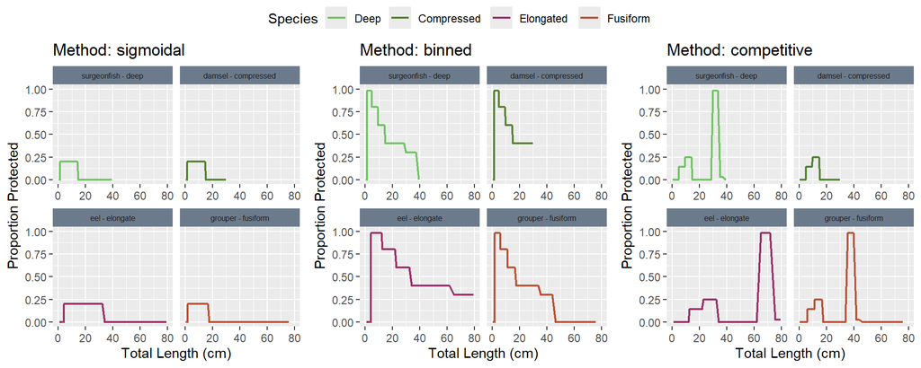

```r
params_comp@other_params$degrade <- FALSE

## Plot with method labels (use plotRefuge and add titles)
g_sig <- plotRefuge(params_sig) + ggplot2::ggtitle('Method: sigmoidal')
g_bin <- plotRefuge(params_bin) + ggplot2::ggtitle('Method: binned')
g_comp <- plotRefuge(params_comp) + ggplot2::ggtitle('Method: competitive')

## Arrange and print
library(ggpubr)
ggpubr::ggarrange(g_sig, g_bin, g_comp, ncol = 3, common.legend = TRUE, legend = 'top')
```

```r
## Optionally save the figure (example from Chapter 3)
# ggsave('bodyshape_methods_refuge_examples.png', plot = last_plot(), width = 27, height = 12, units = 'cm', dpi = 600)
```

The three panels show how the same set of functional groups can receive different protection patterns depending on the chosen method and method-specific parameters. The binned and competitive methods allow fine control across size ranges; the sigmoidal method provides a smooth, parsimonious shape controlled by the threshold length and max protection.

### Changing the refuge profile (examples)

Chapter 3 explores how altering the refuge profile changes model outcomes. Here we show short code snippets that demonstrate the two common ways you might change a refuge profile on an existing `params` object without re-creating everything from scratch.

1. Change the sigmoidal threshold length `L_refuge` or `prop_protect`:

```r
# Update L_refuge and proportion protected for a sigmoidal params object
newRefuge(params_sig, new_refuge = TRUE, new_L_refuge = 20, new_prop_protect = 0.25)
# Recalculate refuge and (if needed) retune steady state: reefSteady(), matchReefGrowth(), etc.
```

2. Scale the binned or competitive bins by a constant (useful for scenario testing, e.g. habitat loss reducing refuge by 50%):

```r
# Scale all bins by 0.5 (50% reduction in protection values)
newRefuge(params_bin, new_refuge = TRUE, scale_bin = 0.5)

# For competitive method, scaling refuge_density will change the availability
# of refuges and therefore the density-dependent allocation.
newRefuge(params_comp, new_refuge = TRUE, scale_bin = 0.5)
```

Notes: - After changing refuge parameters, the model is typically no longer at the previous steady state. To restore steady-state agreement with observed biomasses you will usually re-run the tuning sequence (next section). - Use `plotRefuge()` after `newRefuge()` to visualise the modified profile.

## 3. Unstructured resources

`MizerReef` adds two unstructured resources: `algae` and `detritus`. These are tracked by total biomass (not as a size spectrum). Parameters and important settings include:

- `interaction_algae`, `interaction_detritus` in `species_params`: how much each group feeds on these resources (0–1).
- `initial_algae_growth`: algal production (g/m^2/year). Set via `newReefParams(..., initial_algae_growth = value)` or left as default.
- `algae_capacity`, `detritus_capacity`: carrying capacities when using the carrying-capacity dynamics.

If you need to set or change these after creating a `params` object, use `setURParams()` or pass them into `newReefParams()` when you create the model. See `?setURParams` for details.

## 4. Creating a model with `newReefParams()`

Putting everything together: below is a compact example that creates a `MizerParams` object for the `karpata` example using the sigmoidal refuge method and then runs a short simulation.

```r
# Example (eval = FALSE to avoid running a long simulation in CRAN checks)
params <- newReefParams(group_params = karpata_species,
                        interaction = karpata_int,
                        UR_interaction = data.frame(algae = karpata_species$interaction_algae,
                                                    detritus = karpata_species$interaction_detritus),
                        method = 'sigmoidal',
                        method_params = data.frame(L_refuge = 15, prop_protect = 0.2),
                        refuge_user = karpata_species$refuge_user,
                        bad_pred = karpata_species$bad_pred,
                        satiation = karpata_species$satiation)

# Run a short projection (adjust t_max and effort as needed)
sim <- project(params, t_max = 5, effort = 1)

# Explore results
plot(sim)
plotRefuge(params)
```

Tip: when switching between refuge methods or changing refuge parameters on an existing `params` object, use `newRefuge()` to update the refuge profile and then re-tune steady state components with functions such as `matchReefGrowth()` and `reefSteady()` as described in the package documentation.

## 5. Exploring results

Most plotting and summary functions from `mizer` also work with `MizerReef`. The package adds helper plotting functions for refuge, algae, and detritus (for example `plotRefuge()`, `plotAlgaeConsumption()`, `plotDetritusProduction()`). Use `plot(sim)` for an overview and the specialised helpers for more detail.

## Links and further reading

- The official `mizer` getting started guide: https://sizespectrum.org/mizer/articles/mizer.html
- `MizerReef` reference and articles: https://cmbeese.github.io/mizerReef/
- Functions referenced in this vignette: `newReefParams()`, `setRefuge()`, `getRefuge()`, `newRefuge()`, `setURParams()`.

## Tuning the steady state (overview and references)

Reaching a steady state that matches observed biomasses and growth rates is an iterative process. The tuning approach used for MizerReef follows the 5-step recipe described in the mizer blog: https://blog.mizer.sizespectrum.org/posts/2021-08-20-a-5-step-recipe-for-tuning-the-model-steady-state/

The recipe in brief (see the blog for full details):

1. Start with plausible species parameters and a resource spectrum. Create an initial `params` object with `newReefParams()`.
2. Use `matchBiomasses()` (from mizer) to adjust reproduction parameters so steady-state biomasses match observed values up to the survey cutoff size.
3. Use `matchReefGrowth()` (package helper) to adjust growth-related parameters (e.g. `h`, `k_vb`) so growth rates resemble observations.
4. Tune unstructured-resource parameters (algae, detritus) so that resource production and consumer feeding levels are consistent; helper functions such as `tuneUR_cc()` or `setURcapacity()` can assist.
5. Run `reefSteady()` to find the steady state; check diagnostics and iterate steps 2–4 until the steady state is acceptable.

Important notes: - Tuning is typically done with a noncomplex or a simple tuning refuge profile (for example `tuning_profile` or `step_tune` included in the package) before switching to the full competitive method. - After switching to a density-dependent competitive refuge, remember to iterate matching and steady-state steps because refuge density changes feeding and competition.

## Model description context

For context, here is a short excerpt summarising the model purpose and the role of habitat structure (extracted from the package model description):

“Habitat structure mediates system dynamics by providing predation refuge. The most effective refuges fit prey while excluding predators, so refuge use is primarily governed by body size. In systems with high structural complexity (for example, coral reefs), refuge use patterns are reflected in the size structure of fish assemblages. Because the protection offered by refuges is size-dependent, size-spectrum models provide a natural framework for exploring how benthic structure influences community dynamics. MizerReef modifies predator–prey encounter rates to represent the effects of habitat structure, allowing users to explicitly account for changes in refuge availability caused by habitat degradation or modification.”

See the full package model description vignette (`reef-model_description`) for a complete explanation and references.